# Levels of Aggregation in Election Data

Which rung of the ladder answers which question

Democracy’s Data

Last updated September 13, 2026 at 10:53a EDT

Alaska’s 2024 election for the U.S. House used ranked-choice voting, in which a voter numbers the candidates in order of preference instead of marking one. Somewhere in the state a voter ranked the Republican, Nick Begich, first and the Democrat, Mary Peltola, second. 6,663 others made the same pair of marks in the same order, and 10,771 made it the other way round. Both numbers sit in a public file. Neither can be recovered from the vote totals of the precinct that voter lives in, or of the county, or of the state — not approximately, not with a better method, not ever. Add up the paper and the two numbers are gone.

Every claim about an election is a claim at some level of aggregation. *“Two-thirds of Alaskans used only one ranking”* is about ballots. *“This precinct swung twelve points”* is about precincts. *“Rural counties moved right”* is about counties. *“Trump won 312 electoral votes”* is about states.

These are not four resolutions of one picture. **Each step up the ladder permanently destroys a kind of question and permanently creates a new way to be wrong.** A photograph you zoom out of can be zoomed back in. An aggregate cannot. This chapter walks the ladder rung by rung, and then works one example in full: an estimate made across the gap, scored against a truth that is almost never available.

## The secret ballot is the deliberate destruction of individual-level data

When American states adopted the Australian ballot in the late nineteenth century — a ballot printed by the government, listing every candidate, and marked in private, named for the colonies that used it first — they were not solving a data-management problem badly. They were making it impossible to know how any particular person voted, on purpose, because the alternative was a country in which employers and party bosses could check.

So the finest-grained thing that exists for almost every American election is **the precinct** — a few hundred to a few thousand ballots, added up. Everything we claim to know about *who* votes how, including everything a court is told about racially polarized voting — whether voters of different races are choosing different candidates — under the Voting Rights Act,[^1] is an inference made across that gap. **The gap is the point of the institution and the problem of the method.**

## Where the data comes from, and what it is for

**No American institution publishes the same election at more than one level of aggregation**, because no American institution runs elections. The rungs of the ladder are produced by different bodies, with different obligations and no relationship to one another. A chapter about the relationship between levels therefore has to be assembled, and this one is assembled entirely from files other chapters of this book already downloaded, kept and described. If a number on this page is wrong, it is wrong in the chapter it came from too, which is the property worth wanting.

**Who is in it, and how they got there.** Every ballot cast, but almost always as somebody’s total. A state publishes precinct returns because its own law says so; here that is Georgia, for 2020 and 2024. Counties reach the public through Tony McGovern’s compilation, a private assembly of fifty-one state files (fifty states and the District of Columbia). Congressional-district results are Jason Timm’s reconstruction, and the count of precincts and jurisdictions comes from the Election Assistance Commission’s survey of the offices that run elections. And the only file in which a row is a single ballot exists because Alaska adopted ranked-choice voting and cannot count the election without publishing one.

**Who it was made for.** Certification, not analysis. A return exists so that an official can sign a total and an outcome can take legal effect. Nobody who produced any rung of this ladder was trying to describe voters, and no column in any of these files was designed for the questions this chapter asks of them.

**What it costs to get.** No fees anywhere, and no single place either. The upper rungs are easy; the precinct rung must be assembled state by state in fifty-one formats; the ballot rung exists for one state. What this chapter inherits, it inherits whole: every judgment call those chapters made is silently stacked underneath this one.

**What has already been done to it.** Four decisions, and one of them removes rows. Candidate-name columns (`Kamala D. Harris`, typed by 159 county tabulation systems) become party roles, `dem` and `rep`, because no two elections share a column name. Shares are **two-party** shares — the Democratic vote divided by the Democratic and Republican votes together — so third-party votes count toward no denominator (the bottom number of the fraction) anywhere on this page. The precinct key is county and precinct pasted together, because precinct names repeat across counties. And the Alaska ballots were collapsed to distinct ranking sequences, with precinct and tabulator identifiers dropped, before anything was saved — even the bottom rung here is already an aggregate.

Here are three Georgia precincts after those decisions, every column a role rather than a name:

| Level | Unit | Dem | Rep | Two party votes | Dem share |
| --- | --- | --- | --- | --- | --- |
| precinct | Appling\|1B | 108 | 921 | 1,029 | 10.50 |
| precinct | Appling\|1C | 67 | 724 | 791 | 8.47 |
| precinct | Appling\|2 | 782 | 541 | 1,323 | 59.11 |

| Level | Rows arriving | Rows kept | A row is |
| --- | --- | --- | --- |
| precinct | 2,701 | 2,684 | one polling place’s returns |
| county | 159 | 159 | one county’s returns |
| congressional district | 14 | 14 | one seat in the U.S. House |
| state | 1 | 1 | one state’s returns |

**17 precincts disappear** between arriving and being kept. They cast no two-party votes at all, so their Democratic share is a division by zero rather than a small number. Dropping them is right and it is not free: every precinct count on this page counts precincts *where somebody voted for a major party*, and the difference is 17 places where people live.

## Seven rungs, from a mark on paper to a number on the evening news

158,211,780 ballots were cast in 2024; 177,708 precincts counted them; 6,461 offices ran them; 3,144 counties, 434 districts and 51 states report them; one nation sums them. **Eight orders of magnitude — eight powers of ten from the bottom rung to the top — and every step is one way.**

| Level | Units nationally | In Georgia | A row is | Published for |
| --- | --- | --- | --- | --- |
| ballot | 158,211,780 | — | one voter’s ballot | a handful of jurisdictions |
| precinct | 177,708 | 2,701 | one polling place’s returns | every state, in different formats |
| election jurisdiction | 6,461 | — | one office that runs elections | every state, once every two years |
| county | 3,144 | 159 | one county’s returns | every state except Alaska |
| congressional district | 434 | 14 | one seat in the U.S. House | reconstructed from blocks by third parties |
| state | 51 | 1 | one state’s returns | every state |
| nation | 1 | — | the whole electorate | the country |

The bottom rung deserves a close look, because it is the only American election data in which a row is a person’s ballot. Alaska’s **cast vote record** — the file that lists, for every ballot, each mark made on it — carries every ranking each ballot contained, and 340,778 ballots collapse to only 926 distinct sequences — 65.2% of voters who ranked anyone ranked exactly one candidate and stopped.

| Ranked first | Ranked second | Ballots |
| --- | --- | --- |
| Begich, Nick | Howe, John Wayne | 24,386 |
| Begich, Nick | Peltola, Mary S. | 6,663 |
| Peltola, Mary S. | Hafner, Eric | 39,684 |
| Peltola, Mary S. | Howe, John Wayne | 13,890 |

The pair of numbers that opens this chapter is a crossing of first choice with second choice: a property of two marks on one piece of paper. **No total of any kind contains it.** A precinct that reports how many votes each candidate received has already thrown away which candidates appeared together on a ballot, in a way no later arithmetic undoes.

What the upper rungs buy is everything else. **Coverage**: the whole Alaska file is 0.215% of the country’s 2024 ballots, two in every thousand, and there is no national cast-vote-record file and will not be one. **Comparability**: a presidential series running from 1864 exists at the state level and nowhere finer, because no smaller unit keeps its identity that long. **The unit of the institution**: the electoral college is counted in states and a House seat in districts, so for those questions the total is not a compromise but the object. And **stability**: a precinct of four hundred voters is mostly noise, and a county is not.

Here is one rung climbed by hand. The three precincts shown earlier are three of Appling County’s 9. Add the Democratic column down all 9 and it comes to 1,560; the Republican column comes to 6,761. Those are exactly the two numbers the state’s own county file carries for Appling, 1,560 and 6,761, for a Democratic share of 18.7%. Nothing was lost in the count. What was lost is everything else. The 9 precincts ran from 3.4% Democratic to 59.1%, and one of them, precinct 2, was a Democratic-majority place inside a county that was not. The county row reads 18.7% and carries no trace that precinct 2 exists; given only the county row, no method recovers it.

The climb itself is exact where it can be checked and quietly odd where it cannot. Summing all 2,701 Georgia precincts reproduces the state’s county file to the vote, as Appling did. Summing the country’s county rows lands 10,874 votes short of the certified national total — a seam between compilations that the county-returns brief takes apart. The “county” file is not even all counties: Alaska contributes 37 state house districts and the District of Columbia 7 wards.

And the district rung cannot be reached by adding at all, because precinct returns record no district. It is *rebuilt* by somebody assigning census blocks — the smallest pieces of ground the Census Bureau counts, each small enough to fit inside one district — to districts, and sharing each precinct’s votes out among them: an estimate wearing the clothes of a count.

Read the same election at four rungs and one number survives while another dies:

| Level | Units | Mean dem % | Sd | Min | Max |
| --- | --- | --- | --- | --- | --- |
| precinct | 2684 | 48.90 | 24.68 | 3.4 | 100.0 |
| county | 159 | 48.90 | 20.64 | 8.0 | 84.8 |
| congressional district | 14 | 49.78 | 18.45 | 31.2 | 86.4 |
| state | 1 | 48.89 | 0.00 | 48.9 | 48.9 |

**The mean does not move** — 48.90% across 2,684 precincts, 48.90% across 159 counties, 48.89% for the state. **The spread collapses**, from a standard deviation (the typical distance of a unit from the mean) of 24.7 points to 20.6: Georgia holds precincts at 3.4% and 100.0% Democratic, counties only at 8.0% and 84.8%. From precincts to counties, 30.1% of the variation in Democratic share disappears. That vanished variation is exactly what the next section tries, and fails, to get back.

## Delete the answer, then try to recover it

Georgia is unusual: it publishes candidate and vote method together — a **joint distribution**, a table with the candidates down the side and mail, early and election-day votes across the top — so a question like *what share of mail voters chose Biden* is not a guess. It is a table.

| Candidate | By mail | Not by mail | Total | % of them by mail |
| --- | --- | --- | --- | --- |
| Joseph R. Biden | 849,729 | 1,624,778 | 2,474,507 | 34.3 |
| Donald J. Trump | 451,157 | 2,010,680 | 2,461,837 | 18.3 |
| Jo Jorgensen | 16,057 | 46,081 | 62,138 | 25.8 |

Read the columns the other way round and **64.5% of Georgia’s 2020 mail votes went to Biden**, against 44.1% of everything else. That is the answer key.

**Now delete the table.** Keep only what every other state publishes: for each precinct, the share of votes cast by mail and the share cast for Biden. Fit the best line through that scatter and read it off at 0% mail and at 100% mail. The reading at 100% is what the line says a precinct made up entirely of mail voters would do, which is to say what mail voters do; the reading at 0% is the same for everyone else. That line is Goodman’s **ecological regression**, the workhorse of voting-rights litigation since 1953.[^2]

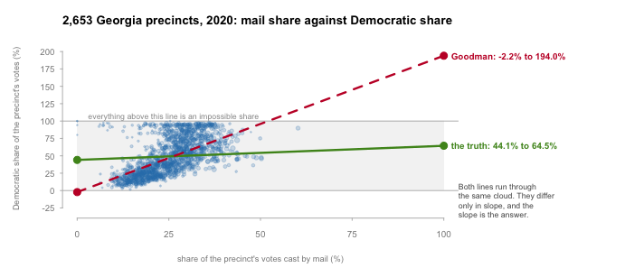

**Figure 1. Two lines through the same cloud of precincts.** Each dot is one of Georgia’s 2,653 precincts in 2020, placed by the share of its votes cast by mail and the share cast for Biden, with dot area following the precinct’s votes. A scatter with two fitted lines is the shape this problem has, because the method’s whole claim is that a slope across places reveals the behavior of people. So the honest picture is the cloud, the line Goodman fits to it (dashed), and the line the published truth draws through it (solid). The shaded band is the range a share can occupy. The dashed line leaves it.

**Goodman’s regression, run on the precinct margins, says 194.0% of Georgia’s mail voters chose Biden** — against a published truth of 64.5%, off by 129.5 points, and a share that cannot exist. Nothing in the aggregate data announces this. The correlation — a number between −1 and 1 saying how tightly the dots follow a line — is 0.60, and the fitted line runs straight through the middle of the cloud. But so does the true line. The two differ only in slope, and the slope is the entire answer.

The reason is not a bug. Precincts with a lot of mail voting were Democratic precincts, and Democratic precincts were more Democratic *among mail voters and election-day voters alike*. The regression cannot tell “mail voters are Democrats” from “Democratic places mailed more,” so it charges the whole between-precinct difference to the method of voting. That is **the ecological fallacy**, guessing what individuals did from group totals, which Robinson (1950) demonstrated on literacy and immigration: states with more immigrants had higher literacy, yet immigrants themselves were less literate than the native-born, because immigrants had settled in states that were literate already.[^3] Here it is in an election, with the answer key attached.

Climb one more rung and it gets worse. Aggregate the same ballots into counties and run the same method:

| Level | Units | R | Goodman says (%) | The truth (%) | Bound, lower | Bound, upper |
| --- | --- | --- | --- | --- | --- | --- |
| precinct | 2653 | 0.599 | 194.0 | 64.5 | 15.2 | 98.4 |
| county | 159 | 0.760 | 233.4 | 64.5 | 6.6 | 99.4 |

**233.4%.** The same ballots, grouped more coarsely, and the answer moves a further 39.4 points from a truth that never changed. The correlation *rises*, from 0.599 to 0.760 — the standard result that ecological correlations exceed individual ones, which is why they tempt. Is that a fact about voters, or about where Georgia drew its county lines? Regroup the same 2,653 precincts into 159 *random* groups, 500 times over:

| Grouping | Units | Correlation | Note |
| --- | --- | --- | --- |
| 2,653 precincts, ungrouped | 2653 | 0.599 | the finest unit with published returns |
| 159 real counties | 159 | 0.760 | the same ballots, grouped by county line |
| 159 random groups of precincts (mean of 500 draws) | 159 | 0.605 | range 0.439 to 0.739; 0 of 500 draws reach the county figure |

Random groups of the same size leave the correlation where it was, at 0.605 on average against 0.599 for the ungrouped precincts. Georgia’s real counties push it to 0.760, which none of the 500 regroupings reached. So the lift is produced not by adding up as such but by adding up along *these particular lines* — Openshaw’s **modifiable areal unit problem**,[^4] the subject of its own chapter in this book.

One thing the aggregate still supports honestly. Duncan and Davis (1953) showed the margins alone put hard bounds on the truth with no model at all:[^5] in each precinct, mail voters cannot have given Biden more votes than there were mail ballots, nor fewer than the Biden votes left over after every non-mail ballot is assumed to be his. Add those limits across precincts and the answer must lie between 15.2% and 98.4%. Wide, useless for litigation, and **correct**, which the regression was not.

And the failure appears where it counts. In a Georgia county whose voter file records race, 4,293 of 4,631 Black voters took a Democratic primary ballot — a truth of 92.7%. Goodman’s regression on the same precincts returns 102.1%: impossible again, this time by 9.4 points, on exactly the kind of precinct evidence that *Thornburg v. Gingles* (1986) lets courts rest a racially-polarized-voting finding on.[^6] Freedman and colleagues (1991) pressed this objection in court;[^7] King (1997) built the standard method that tries to answer it;[^8] the argument is not settled, and the RPV chapter runs it in full.

## Choosing a rung

Everything above compresses into a single working rule: **name the rung before naming the finding**, and say why it is the rung the question lives on. Then check whether the answer survives being asked one rung up. Goodman’s estimate did not — it moved 39.4 points from precincts to counties, on ballots that never changed.

| The question | The rung | Why that one | The trap |
| --- | --- | --- | --- |
| Did Begich voters who ranked a second choice prefer Peltola or Howe? | ballot | The two rankings must sit on the same ballot. No total can restore them. | Precinct returns for an RCV race give round-by-round totals, not pairs. |
| What share of a candidate’s votes arrived by mail? | ballot, or precinct-by-method returns | It is a joint distribution. Georgia publishes it; most states do not. | Regressing precinct Dem share on precinct mail share returns 194%. |
| Is voting in this county racially polarized? | precinct | Smallest unit with returns; demographics attach through blocks. | The estimate is an inference, not a measurement. Report the bounds. |
| Which neighbourhoods swung between two elections? | precinct | County hides the variation; but check the boundary did not move. | A precinct that ‘swung’ may just have gained three hundred houses. |
| Which doors should a campaign knock on Saturday? | precinct | Fine enough to route a walk list, coarse enough to be stable. | A precinct is not a person; targeting is a bet on an average. |
| How many mail ballots were rejected, and for what reason? | election jurisdiction | The jurisdiction is what administers and reports rejection. | ‘Jurisdiction’ is a township in Wisconsin and a county in Texas. |
| Did counties with less education move right? | county | ‘County’ is the unit the education measure is published on. | Robinson (1950): the county pattern need not hold for county residents. |
| Does this map convert votes into seats fairly? | congressional district | The seat is the district. Precincts must be aggregated into it first. | Districts do not nest into counties; someone had to disaggregate blocks. |
| Who won the presidency? | state | The electoral college is counted in states, not in voters. | The popular vote is not the quantity being decided. |
| Is the country’s partisan balance shifting across decades? | nation | Only the top rung gives one comparable number over a long series. | Anything below the top rung has changed shape underneath the series. |

## What this data cannot tell you

**It cannot tell you how any person voted.** That is not a limitation to engineer around; it is the secret ballot working. The demand for individual-level election data is a demand to partly undo a democratic achievement. Texas’s 2024 emergency guidance on cast-vote-record releases,[^9] and the litigation ordering such releases elsewhere, are both defensible positions in that live conflict.

**One state carries most of the walk.** Georgia publishes precinct returns by vote method and most states do not. Whether Goodman’s regression fails this badly elsewhere is not shown here and should not be assumed — what is shown is that the failure mode is real, large, and silent.

**One contest carries the bottom rung.** Alaska’s cast vote record exists because the election was ranked-choice, so nothing here says what such a record would reveal about an ordinary plurality race.

**The district rung is borrowed rather than built.** It arrives as percentages with no vote counts, so its mean in the table above is unweighted — every district counting once — while every other rung’s is weighted by votes. That is a difference in construction, not a finding about districts.

**And vote method is not a demographic.** “Mail voter” is a behavior with no census count behind it. The racially polarized case, where the group is fixed, the stakes are a federal remedy, and the answer key almost never exists, is harder than the case worked here, not easier.

## What you should have learned

- Election data comes on a ladder (ballot, precinct, jurisdiction, county, district, state, nation), and each step up is irreversible: the 6,663 Begich-then-Peltola ballots of the opening cannot be recovered from any total.
- Aggregation preserves the mean and destroys the spread: Georgia’s Democratic share is 48.90% at every rung, while 30.1% of the precinct-level variation vanishes by the county rung.
- Ecological regression on Georgia’s precinct margins estimated that 194.0% of mail voters chose Biden, against a published truth of 64.5% — an impossible share, delivered without warning, and coarser grouping made it worse, not better.
- The grouping lines matter as much as the grouping size: 500 random regroupings of the same precincts averaged a correlation of 0.605, and none reached the 0.760 produced by Georgia’s actual county lines.
- The honest aggregate answer is a bound, not a point: the margins alone put Georgia’s mail vote between 15.2% and 98.4% Democratic, which is wide, nearly useless, and correct.

## Where this data appears in this book

What Election Returns Can and Cannot Show leads this cluster and states the instrument’s limits; this chapter supplies its ladder and its graded ecological exhibit. The cluster’s briefs each work on one or two rungs:

- Fifty-One Publishers, One Election — what it costs to assemble the county file no agency publishes.
- What the Panhandle Did — a claim about race and a primary, tested against returns at several rungs.
- Where Electoral Votes Are, and Where They Are Contested — the state rung, where the electoral college lives.
- Mapping Votes Against Land Area — the county rung drawn four ways.
- Mapping Vote Swing Between Elections — county-level change, drawn as arrows.
- A Table That Is Also Fifty-One Charts — the state rung, fifty-one small trends.
- Presidential Returns Across 150 Years — the state rung, the only one with a 150-year series.
- Distributions, and the Summaries That Hide Them — the district rung, four hundred districts against one average.
- How Much of 2024 Was Already Decided in 2020 — one election against the next at the state and district rungs.
- One Election, Not Fifty — nationalization, measured across rungs.
- Bellwether Counties, 1960–2024 — the county rung, and why a perfect record predicts nothing.
- The Arithmetic of Vote Targeting — the precinct rung, put to campaign work.
- Georgia Precinct Returns and the 2020 Recount — the precinct file this chapter reads, and its vote-method columns.
- Comparing Precincts Across Two Elections — why the precinct rung does not hold still between elections.
- Cast Vote Records and Ranked-Choice Counting — the ballot rung, recounted from the Alaska file used here.
- Residual Votes and Ballot Design — the jurisdiction rung, and the subtraction no agency performs.
- The Election Administration and Voting Survey — the survey behind this chapter’s counts of precincts and jurisdictions.

## Sources

**Data.** Nothing here was downloaded. Every number above is re-derived from files other chapters of this book already downloaded and kept, and each of those chapters says where its file came from. The publishers underneath are these.

- State of Alaska, Division of Elections, 2024 general election cast vote record — the bottom rung, one row per distinct ranking sequence. https://www.elections.alaska.gov/results/24GENR/
- Georgia Secretary of State, certified precinct returns for the 2020 and 2024 general elections, with the 2020 vote-method breakdown. https://sos.ga.gov/page/historical-elections-results
- Tony McGovern, *United States General Election Presidential Results by District, Ward, or County from 2008 to 2024* — county and state returns for the whole country. https://github.com/tonmcg/US_County_Level_Election_Results_08-24
- Jason Timm, *PresElectionResults* — results by congressional district for 2024, and the national series back to 1864. https://github.com/jaytimm/PresElectionResults
- U.S. Election Assistance Commission, *Election Administration and Voting Survey* — the national counts of each kind of unit. https://www.eac.gov/research-and-data/datasets-codebooks-and-surveys
- Houston County, Georgia, General Primary of 21 May 2024, with self-reported race — the graded ecological case. A public record in Georgia, obtained as working material rather than downloaded, and described where this book first uses it, in the RPV chapter.

Also cited: Texas Secretary of State, *Election Advisory No. 2024-20*, emergency guidance on voter privacy, 6 June 2024.

**The data itself**

Every figure above is drawn from these tables. They are plain CSV, they open in a spreadsheet, and they are yours to take further.

`consistency.csv`, `cvr_facts.csv`, `cvr_second.csv`, `decision.csv`, `eco_county.csv`, `eco_estimates.csv`, `eco_precinct.csv`, `ga_levels.csv`, `ladder.csv`, `level_stats.csv`, `maup_draws.csv`, `maup_null.csv`, `method_truth.csv`, `not_counties.csv`, `rpv_check.csv`, `seat_vote.csv`, `suitability.csv`

**Your turn**

None of these is answered above, and every one can be answered from the tables you just opened.

- `suitability.csv` scores each `question` against each `level` of the ladder in its `fit` column. Pick a question you care about and find the rung that fits. Then check what the published data actually offers at that rung.
- `eco_estimates.csv` shows what an ecological estimate gets wrong, with `truth_by_mail` beside `est_by_mail`. Work out the size of the error at each level. Would you have known it was wrong without the truth column?
- `maup_draws.csv` recomputes the same `correlation` on many random groupings. Look at the spread. How much of a published correlation is the grouping rather than the people?
- `ladder.csv` gives `share_of_voters_pct` and what each rung is `published_for`. Find the rung where publication stops. What questions die there?

**Academic literature**

- Robinson, W. S. (1950). “Ecological Correlations and the Behavior of Individuals.” *American Sociological Review* 15(3): 351–357. https://www.jstor.org/stable/2087176
- Goodman, L. A. (1953). “Ecological Regressions and Behavior of Individuals.” *American Sociological Review* 18(6): 663–664. https://www.jstor.org/stable/2088121
- Duncan, O. D. and Davis, B. (1953). “An Alternative to Ecological Correlation.” *American Sociological Review* 18(6): 665–666. https://www.jstor.org/stable/2088122
- Goodman, L. A. (1959). “Some Alternatives to Ecological Correlation.” *American Journal of Sociology* 64(6): 610–625. https://www.jstor.org/stable/2773199
- Openshaw, S. (1984). *The Modifiable Areal Unit Problem.* Concepts and Techniques in Modern Geography 38. Norwich: Geo Books.
- Freedman, D. A., Klein, S. P., Sacks, J., Smyth, C. A. and Everett, C. G. (1991). “Ecological Regression and Voting Rights.” *Evaluation Review* 15(6): 673–711.
- King, G. (1997). *A Solution to the Ecological Inference Problem: Reconstructing Individual Behavior from Aggregate Data.* Princeton: Princeton University Press. https://press.princeton.edu/books/paperback/9780691012407/a-solution-to-the-ecological-inference-problem
- *Thornburg v. Gingles*, 478 U.S. 30 (1986). https://www.law.cornell.edu/supremecourt/text/478/30
- Voting Rights Act of 1965, §2, 52 U.S.C. §10301. https://www.law.cornell.edu/uscode/text/52/10301
[^1]: Section 2 of the Act, 52 U.S.C. §10301: https://www.law.cornell.edu/uscode/text/52/10301.
[^2]: Leo A. Goodman, “Ecological Regressions and Behavior of Individuals,” *American Sociological Review* 18, no. 6 (1953): 663–664, https://www.jstor.org/stable/2088121.
[^3]: W. S. Robinson, “Ecological Correlations and the Behavior of Individuals,” *American Sociological Review* 15, no. 3 (1950): 351–357, https://www.jstor.org/stable/2087176.
[^4]: Stan Openshaw, *The Modifiable Areal Unit Problem*, Concepts and Techniques in Modern Geography 38 (Norwich: Geo Books, 1984).
[^5]: Otis Dudley Duncan and Beverly Davis, “An Alternative to Ecological Correlation,” *American Sociological Review* 18, no. 6 (1953): 665–666, https://www.jstor.org/stable/2088122.
[^6]: *Thornburg v. Gingles*, 478 U.S. 30 (1986): https://www.law.cornell.edu/supremecourt/text/478/30.
[^7]: David A. Freedman, Stephen P. Klein, Jerome Sacks, Charles A. Smyth and Charles G. Everett, “Ecological Regression and Voting Rights,” *Evaluation Review* 15, no. 6 (1991): 673–711, doi:10.1177/0193841X9101500601.
[^8]: Gary King, *A Solution to the Ecological Inference Problem: Reconstructing Individual Behavior from Aggregate Data* (Princeton: Princeton University Press, 1997), https://press.princeton.edu/books/paperback/9780691012407/a-solution-to-the-ecological-inference-problem.
[^9]: Texas Secretary of State, *Election Advisory No. 2024-20*, 6 June 2024: https://www.sos.state.tx.us/elections/laws/advisory2024-20.shtml.